# Correlates of Protection for Cholera study progress report

Last updated: 29 April 2025 12:11 PM EDT

## Study enrollment summary

The goal of the tables below are to summarize the current status of subject enrollment into the study and identify any delays in the follow-up visits to current student participants.

Table 1 shows that 102 individuals have been screened into the study and 1 individual(s) was ineligible.

Table 1: Participant eligibility summary

| scr_elig_status | count |
| --- | --- |
| Eligible | 101 |
| Ineligible and CAN be rescreened | 1 |

Table 2 shows that among the 101 eligible study participants, they have been divided into the two arms of the study based on the vaccine administered. Participant demographic data (age and sex) are summarized by study arm. Participants that have completed the study or withdrawn early will complete a Subject Status Form. This table also tracks the individuals that have delayed follow-up (>24 days) based on their scheduled visits from their date of enrollment.

Table 2: Study enrollment summary

| Description | Group | Cholera (OCV) | Typhoid (TCV) | Total |
| --- | --- | --- | --- | --- |
| Total eligible participants | total | 43 | 58 | 101 |
| Age bin | [2,5) | 27 | 38 | 65 |
| Age bin | [5,14) | 16 | 20 | 36 |
| Sex | Female | 26 | 31 | 57 |
| Sex | Male | 17 | 27 | 44 |
| Completed study | FALSE | 43 | 58 | 101 |
| Withdrawn from study | FALSE | 42 | 57 | 99 |
| Withdrawn from study | TRUE | 1 | 1 | 2 |

Table 3 displays the status of participants with delayed follow-up visits (>24 days). The `min_date` column shows the date of their enrollment and the `max_date` column shows the date of their latest follow-up visit (across all forms).

```
## [1] "No current participants with >24 days delayed follow-up"
```

```
## [1] "No table to download"
```

## Weekly diarrhea checks

This notebook will also keep track of the weekly phone calls to participants for diarrhea checks.

Table 4: Weekly phone calls

| vxf_arm | wia_week | wia_diarrheanow | wia_diarrheasince | n |
| --- | --- | --- | --- | --- |
| NA | Phone Call 1 (Day 51) | No | No | 47 |
| NA | Phone Call 2 (Day 58) | No | No | 10 |

## Missing visits

Table 5 and Figure 1 will show the prospectively scheduled visits for each eligible study participants and whether those visits have been completed, still pending, or are overdue. If participants have an overdue visit but have had a more recent visit (≤24 days from today’s date), they will not appear in Table 3 above.

Table 5: Record ID status

| record_id | vxf_arm | scr_date | v1_d0 | v2_d3 | v3_d7 | v4_d14 | v5_d21 | v6_d44 | v7_d90 | v8_d180 | v9_d270 | v10_d360 | v11_d450 | v12_d540 | v13_d630 | v14_d720 |
| --- | --- | --- | --- | --- | --- | --- | --- | --- | --- | --- | --- | --- | --- | --- | --- | --- |
| 1 | Typhoid (TCV) | 2025-03-02 | complete | complete | complete | not eligible | complete | complete | pending, due in 32 days | pending, due in 122 days | pending, due in 212 days | pending, due in 302 days | pending, due in 392 days | pending, due in 482 days | pending, due in 572 days | pending, due in 662 days |
| 2 | Typhoid (TCV) | 2025-03-02 | complete | complete | complete | not eligible | complete | complete | pending, due in 32 days | pending, due in 122 days | pending, due in 212 days | pending, due in 302 days | pending, due in 392 days | pending, due in 482 days | pending, due in 572 days | pending, due in 662 days |
| 3 | Cholera (OCV) | 2025-03-02 | complete | complete | complete | complete | complete | complete | pending, due in 32 days | pending, due in 122 days | pending, due in 212 days | pending, due in 302 days | pending, due in 392 days | pending, due in 482 days | pending, due in 572 days | pending, due in 662 days |
| 4 | Cholera (OCV) | 2025-03-02 | complete | complete | complete | complete | complete | complete, 4 days delayed | pending, due in 32 days | pending, due in 122 days | pending, due in 212 days | pending, due in 302 days | pending, due in 392 days | pending, due in 482 days | pending, due in 572 days | pending, due in 662 days |
| 5 | Typhoid (TCV) | 2025-03-02 | complete | complete | complete | not eligible | complete | complete | pending, due in 32 days | pending, due in 122 days | pending, due in 212 days | pending, due in 302 days | pending, due in 392 days | pending, due in 482 days | pending, due in 572 days | pending, due in 662 days |
| 6 | Typhoid (TCV) | 2025-03-02 | complete | complete | complete | not eligible | complete | complete | pending, due in 32 days | pending, due in 122 days | pending, due in 212 days | pending, due in 302 days | pending, due in 392 days | pending, due in 482 days | pending, due in 572 days | pending, due in 662 days |
| 7 | Cholera (OCV) | 2025-03-02 | complete | complete | complete | complete | complete | complete | pending, due in 32 days | pending, due in 122 days | pending, due in 212 days | pending, due in 302 days | pending, due in 392 days | pending, due in 482 days | pending, due in 572 days | pending, due in 662 days |
| 8 | Typhoid (TCV) | 2025-03-02 | complete | complete | complete | not eligible | complete | complete | pending, due in 32 days | pending, due in 122 days | pending, due in 212 days | pending, due in 302 days | pending, due in 392 days | pending, due in 482 days | pending, due in 572 days | pending, due in 662 days |
| 9 | Cholera (OCV) | 2025-03-02 | complete | complete | complete | complete | complete | complete | pending, due in 32 days | pending, due in 122 days | pending, due in 212 days | pending, due in 302 days | pending, due in 392 days | pending, due in 482 days | pending, due in 572 days | pending, due in 662 days |
| 10 | Cholera (OCV) | 2025-03-02 | complete | complete | complete | complete | complete | complete | pending, due in 32 days | pending, due in 122 days | pending, due in 212 days | pending, due in 302 days | pending, due in 392 days | pending, due in 482 days | pending, due in 572 days | pending, due in 662 days |
| 11 | Typhoid (TCV) | 2025-03-03 | complete | complete | complete | not eligible | complete | complete | pending, due in 33 days | pending, due in 123 days | pending, due in 213 days | pending, due in 303 days | pending, due in 393 days | pending, due in 483 days | pending, due in 573 days | pending, due in 663 days |
| 12 | Cholera (OCV) | 2025-03-03 | complete | complete | complete | complete | complete | complete, 4 days delayed | pending, due in 33 days | pending, due in 123 days | pending, due in 213 days | pending, due in 303 days | pending, due in 393 days | pending, due in 483 days | pending, due in 573 days | pending, due in 663 days |
| 13 | Typhoid (TCV) | 2025-03-03 | complete | complete | complete | not eligible | complete | complete | pending, due in 33 days | pending, due in 123 days | pending, due in 213 days | pending, due in 303 days | pending, due in 393 days | pending, due in 483 days | pending, due in 573 days | pending, due in 663 days |
| 14 | Typhoid (TCV) | 2025-03-03 | complete | complete | complete | not eligible | complete | complete | pending, due in 33 days | pending, due in 123 days | pending, due in 213 days | pending, due in 303 days | pending, due in 393 days | pending, due in 483 days | pending, due in 573 days | pending, due in 663 days |
| 15 | Cholera (OCV) | 2025-03-03 | complete | complete | complete | complete | complete | complete | pending, due in 33 days | pending, due in 123 days | pending, due in 213 days | pending, due in 303 days | pending, due in 393 days | pending, due in 483 days | pending, due in 573 days | pending, due in 663 days |
| 16 | Typhoid (TCV) | 2025-03-03 | complete | complete | complete | not eligible | complete | complete | pending, due in 33 days | pending, due in 123 days | pending, due in 213 days | pending, due in 303 days | pending, due in 393 days | pending, due in 483 days | pending, due in 573 days | pending, due in 663 days |
| 17 | Typhoid (TCV) | 2025-03-03 | complete | complete | complete | not eligible | complete | complete | pending, due in 33 days | pending, due in 123 days | pending, due in 213 days | pending, due in 303 days | pending, due in 393 days | pending, due in 483 days | pending, due in 573 days | pending, due in 663 days |
| 19 | Typhoid (TCV) | 2025-03-03 | complete | complete | complete | not eligible | complete | complete | pending, due in 33 days | pending, due in 123 days | pending, due in 213 days | pending, due in 303 days | pending, due in 393 days | pending, due in 483 days | pending, due in 573 days | pending, due in 663 days |
| 20 | Cholera (OCV) | 2025-03-03 | complete | complete | complete | complete | complete | complete | pending, due in 33 days | pending, due in 123 days | pending, due in 213 days | pending, due in 303 days | pending, due in 393 days | pending, due in 483 days | pending, due in 573 days | pending, due in 663 days |
| 21 | Typhoid (TCV) | 2025-03-03 | complete | complete | complete | not eligible | complete | complete | pending, due in 33 days | pending, due in 123 days | pending, due in 213 days | pending, due in 303 days | pending, due in 393 days | pending, due in 483 days | pending, due in 573 days | pending, due in 663 days |
| 22 | Cholera (OCV) | 2025-03-03 | complete | complete | complete | complete | complete | complete | pending, due in 33 days | pending, due in 123 days | pending, due in 213 days | pending, due in 303 days | pending, due in 393 days | pending, due in 483 days | pending, due in 573 days | pending, due in 663 days |
| 23 | Typhoid (TCV) | 2025-03-03 | complete | complete | complete | not eligible | complete | complete | pending, due in 33 days | pending, due in 123 days | pending, due in 213 days | pending, due in 303 days | pending, due in 393 days | pending, due in 483 days | pending, due in 573 days | pending, due in 663 days |
| 24 | Typhoid (TCV) | 2025-03-03 | complete | complete | complete | not eligible | complete | complete | pending, due in 33 days | pending, due in 123 days | pending, due in 213 days | pending, due in 303 days | pending, due in 393 days | pending, due in 483 days | pending, due in 573 days | pending, due in 663 days |
| 25 | Cholera (OCV) | 2025-03-03 | complete | complete | complete | complete | complete | complete | pending, due in 33 days | pending, due in 123 days | pending, due in 213 days | pending, due in 303 days | pending, due in 393 days | pending, due in 483 days | pending, due in 573 days | pending, due in 663 days |
| 26 | Typhoid (TCV) | 2025-03-03 | complete | complete | complete | not eligible | complete | complete | pending, due in 33 days | pending, due in 123 days | pending, due in 213 days | pending, due in 303 days | pending, due in 393 days | pending, due in 483 days | pending, due in 573 days | pending, due in 663 days |
| 27 | Typhoid (TCV) | 2025-03-03 | complete | complete | complete | not eligible | complete | complete | pending, due in 33 days | pending, due in 123 days | pending, due in 213 days | pending, due in 303 days | pending, due in 393 days | pending, due in 483 days | pending, due in 573 days | pending, due in 663 days |
| 28 | Typhoid (TCV) | 2025-03-03 | complete | complete | complete | not eligible | complete | complete | pending, due in 33 days | pending, due in 123 days | pending, due in 213 days | pending, due in 303 days | pending, due in 393 days | pending, due in 483 days | pending, due in 573 days | pending, due in 663 days |
| 29 | Cholera (OCV) | 2025-03-03 | complete | complete | complete | complete | complete | complete | pending, due in 33 days | pending, due in 123 days | pending, due in 213 days | pending, due in 303 days | pending, due in 393 days | pending, due in 483 days | pending, due in 573 days | pending, due in 663 days |
| 30 | Typhoid (TCV) | 2025-03-03 | complete | complete | complete | not eligible | complete | complete | pending, due in 33 days | pending, due in 123 days | pending, due in 213 days | pending, due in 303 days | pending, due in 393 days | pending, due in 483 days | pending, due in 573 days | pending, due in 663 days |
| 31 | Typhoid (TCV) | 2025-03-03 | complete | complete | complete | not eligible | complete | complete, 5 days delayed | pending, due in 33 days | pending, due in 123 days | pending, due in 213 days | pending, due in 303 days | pending, due in 393 days | pending, due in 483 days | pending, due in 573 days | pending, due in 663 days |

[output cut: 69 more lines]

Table 6 summarizes the total missed visits by study vaccine arm and study timepoint.

Table 6: Record ID status summary

| days_past | redcap_event_name | vxf_arm | n_complete | n_overdue | n_pending |
| --- | --- | --- | --- | --- | --- |
| 0 | Screening Visit 1 (Day 0) | Cholera (OCV) | 42 | 0 | 0 |
| 0 | Screening Visit 1 (Day 0) | Typhoid (TCV) | 57 | 0 | 0 |
| 3 | Visit 2 (Day 3) | Cholera (OCV) | 42 | 0 | 0 |
| 3 | Visit 2 (Day 3) | Typhoid (TCV) | 57 | 0 | 0 |
| 7 | Visit 3 (Day 7) | Cholera (OCV) | 42 | 0 | 0 |
| 7 | Visit 3 (Day 7) | Typhoid (TCV) | 57 | 0 | 0 |
| 14 | Visit 4 (Day 14) | Cholera (OCV) | 31 | 0 | 11 |
| 14 | Visit 4 (Day 14) | Typhoid (TCV) | 0 | 0 | 0 |
| 21 | Visit 5 (Day 21) Home Visit | Cholera (OCV) | 31 | 0 | 11 |
| 21 | Visit 5 (Day 21) Home Visit | Typhoid (TCV) | 36 | 0 | 14 |
| 44 | Visit 6 (Day 44) | Cholera (OCV) | 23 | 0 | 19 |
| 44 | Visit 6 (Day 44) | Typhoid (TCV) | 24 | 0 | 33 |
| 90 | Visit 7 (Day 90) | Cholera (OCV) | 0 | 0 | 42 |
| 90 | Visit 7 (Day 90) | Typhoid (TCV) | 0 | 0 | 57 |
| 180 | Visit 8 (Day 180) | Cholera (OCV) | 0 | 0 | 42 |
| 180 | Visit 8 (Day 180) | Typhoid (TCV) | 0 | 0 | 57 |
| 270 | Visit 9 (Day 270) | Cholera (OCV) | 0 | 0 | 42 |
| 270 | Visit 9 (Day 270) | Typhoid (TCV) | 0 | 0 | 57 |
| 360 | Visit 10 (Day 360) | Cholera (OCV) | 0 | 0 | 42 |
| 360 | Visit 10 (Day 360) | Typhoid (TCV) | 0 | 0 | 57 |
| 450 | Visit 11 (Day 450) | Cholera (OCV) | 0 | 0 | 42 |
| 450 | Visit 11 (Day 450) | Typhoid (TCV) | 0 | 0 | 57 |
| 540 | Visit 12 (Day 540) | Cholera (OCV) | 0 | 0 | 42 |
| 540 | Visit 12 (Day 540) | Typhoid (TCV) | 0 | 0 | 57 |
| 630 | Visit 13 (Day 630) | Cholera (OCV) | 0 | 0 | 42 |
| 630 | Visit 13 (Day 630) | Typhoid (TCV) | 0 | 0 | 57 |
| 720 | Visit 14 (Day 720) | Cholera (OCV) | 0 | 0 | 42 |
| 720 | Visit 14 (Day 720) | Typhoid (TCV) | 0 | 0 | 57 |

Figure 1 shows the rolling status of visits to enrollees. If the planned visit has been completed, the actual visit date is marked with a filled circle. If the visit is late being completed, the planned date is marked with a triangle. If the planned visit is pending, i.e., it is a future date, the planned date is marked with an open circle. The grey vertical line on the plot is centered at today’s date.

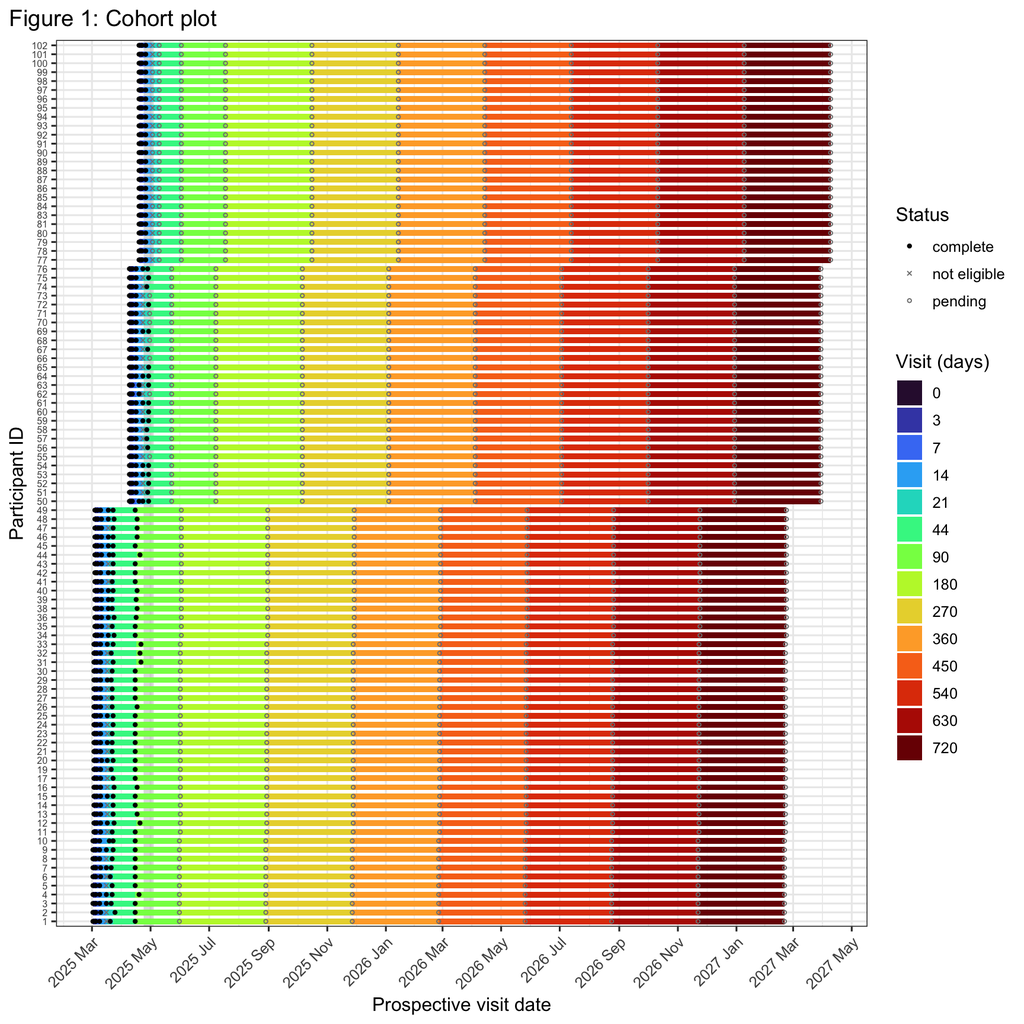